# County-Level Dynamics and Predictors of Drug Overdose Death in the United States (2015-2020)

BMIN 5030 Final Project

Chris Miller

2022-12-07

# Overview

The association between region-specific prescription opioid prescribing and the rate of opioid overdose death was well documented during the time periods when prescription opioids were the primary cause of overdose deaths. However, the role of regional prescribing practices has been less studied since illicit opioids became the primary causes of opioid overdose deaths. The goals of this project are (1) to characterize the dynamics of opioid overdose deaths in the United States from 2015 to 2020, (2) to evaluate county-level changes in opioid dispensing practices, and (3) to determine the relative impact of regional prescription opioid prescribing and health indicators (e.g., depression, obesity, lack of health insurance, smoking, binge drinking, self-reported poor mental health) on overdose death.

# Introduction

The opioid overdose epidemic in the United States has transitioned over the past two decades from being primarily driven by misuse and abuse of prescription opioid analgesics in the early 2000s to one driven by heroin in the mid 2010s and by illicit fentanyl and fentanyl analogs after 2016 ([Hedegaard et al, 2020](https://www.cdc.gov/nchs/data/databriefs/db394-H.pdf)). In recognition of the crisis, federal agencies and professional associations modified recommendations and practice guidelines to minimize unnecessary exposures to prescription opioids for acute and chronic pain ([Dowell et al, 2016](https://www.cdc.gov/mmwr/volumes/65/rr/rr6501e1.htm), [Dowell et al, 2022](https://www.cdc.gov/mmwr/volumes/71/rr/rr7103a1.htm)). Since 2010, the morphine milligram equivalents (MMEs) of opioids dispensed per person has declined nationally by more than 40% ([American Medical Association, 2021](https://end-overdose-epidemic.org/wp-content/uploads/2021/09/AMA-2021-Overdose-Epidemic-Report_92021.pdf)). However, there remains substantial regional variation across the country in opioid prescribing and the rate of overdose deaths attributable to commonly prescribed opioids has not declined since its peak in 2010 ([Mattson et al, 2021](https://www.cdc.gov/mmwr/volumes/70/wr/mm7006a4.htm?s_cid=mm7006a4_w)).

Previous studies have demonstrated that the regional rate of opioid prescribing per capita was highly associated with the regional rate of opioid overdose deaths when prescription opioids were the primary cause of overdose deaths ([Bohnert et al, 2014](https://journals.lww.com/clinicalpain/Fulltext/2014/07000/Trends_and_Regional_Variation_in_Opioid_Overdose.8.aspx); [Madarai et al, 2013](https://www.sciencedirect.com/science/article/abs/pii/S0376871613000185?via%3Dihub)). But with the dramatic increase in heroin- and fentanyl-related overdose deaths, the relationship between regional patterns in prescription opioid prescribing and all-cause opioid overdose death (i.e, due to prescription or illicit opioids) have not continued to be well characterized. This is despite the fact that one of the primary pathways to illicit opioid use continues to be misuse of prescription opioids ([Soffin et al, 2019](https://www.sciencedirect.com/science/article/pii/S0007091218313382)). While there are many paths to the development of an opioid use disorder, many individuals initiate the misuse or abuse of opioids on account of psychological factors such as depression, anxiety, or social isolation (Martins et al, 2011), and nonmedical opioid use frequently co-occurs with abuse of other substances such as alcohol and marijuana ([Fiellin et al, 2013](https://www.sciencedirect.com/science/article/pii/S1054139X12002315?casa_token=X8lLhiPwALQAAAAA:3ZN_dopZfVmSzq2oZfAk90V4Z0bLGzRYa3NvMUUzjjxNFn7vpeUtCTODoe_Rz-F4D-7Is-fbKd0)).

The Centers for Disease Control and Prevention (CDC) maintains publicly available databases that report cause-specific opioid overdose death rates by state (Vital Statistics Rapid Release [VSRR]), county-level opioid dispensing rates (IQVIA Xponent), county-level drug overdose mortality rates (National Center for Health Statistics [NCHS]), and county-specific data on several social determinants of health (PLACES). This collection of data sources facilitates an updated evaluation of the relationships between opioid overdose deaths, prescription opioid prescribing, and community-level health issues.

# Methods

Changes in opioid overdose deaths by type (i.e., prescription opioid, heroin, or synthetic opioid) from 2015 to 2020 were characterized using [VSRR data](https://data.cdc.gov/NCHS/VSRR-Provisional-Drug-Overdose-Death-Counts/xkb8-kh2a/) on drug overdose deaths. Line plots of the number of individuals who died of an overdose by drug type in the US were generated to provide rationale for the key study questions.

To evaluate changes in the dynamics of recent opioid prescribing, county-level opioid dispensing tables reported on the [CDC website](https://www.cdc.gov/drugoverdose/rxrate-maps/index.html) were transferred into Excel files by year. These files were merged with county-level geometry data by FIPS code to create choropleth maps by year.

Data on county-level health indicators were extracted from the [PLACES dataset](https://chronicdata.cdc.gov/500-Cities-Places/PLACES-Local-Data-for-Better-Health-County-Data-20/swc5-untb/data) available on the CDC website. Relevant variables from this dataset in 2020 were aggregated with the county-level opioid prescribing dataset and the drug overdose by FIPS code

County-level data on opioid-specific overdose mortality are not publicly available, but county-level data on drug overdose over time is available from the [National Center for Health Statistics](https://data.cdc.gov/NCHS/NCHS-Drug-Poisoning-Mortality-by-County-United-Sta/pbkm-d27e). Despite the limitation of the lack of county-level data on opioid overdose deaths specifically, the preponderance of drug overdose deaths in the US are attributable to prescription or illicit opioids. For example, in 2020 there were 95,452 drug overdose deaths of which 71,487 (74.9%) were due to opioids. Therefore, county-level drug overdose deaths were used as a surrogate to evaluate the relationship between prescription opioid prescribing and social determinants of health on opioid overdose death in 2020.

The relationships between these variables were characterized in univariable and multivariable linear regression models to evaluate the relative contribution of various factors in county-level drug overdose mortality rates. The specific county-level health indicators included the following variables in adults: binge drinking prevalence, depression prevalence, current smoking status, lack of health insurance, obesity prevalence, self-reported lack of leisure time, and self-reported poor recent physical health. To facilitate clinically relevant interpretations of regression coefficients, the opioid dispensing rate was scaled to reflect a 10-person per 100 resident change and prevalence variables were scaled to reflect a 5 percentage point change.

At various times throughout this project, I consulted with Dr. John Farrar, Professor of Epidemiology at the University of Pennsylvania, who is an expert in treatments for pain. My GitHub repository containing all information needed to reproduce these analyses as well as this HTML file can be found [here](https://github.com/cjm2718/BMIN503_Final_Project).

```r
knitr::opts_chunk$set(echo = TRUE)
knitr::opts_knit$set(root.dir = "C:\\Users\\cjm2718\\Dropbox\\Penn\\BMIN 5030\\Final Project Data\\")
library(tidyverse)
library(ggplot2)
library(GGally)
library(sf)
library(tidycensus)
library(leaflet)
library(RColorBrewer)
library(readxl)
library(gridExtra)
library(grid)
library(clinUtils)
library(plotly)
library(gtsummary)
library(kableExtra)
library(viridis)
library(glmnet)
library(car)
library(lubridate)
library(caret)

## import county-level prescription opioid dispensing rates by year
county.disp.2015 <- read_excel("county_dispensing_rates_2015.xlsx")
county.disp.2016 <- read_excel("county_dispensing_rates_2016.xlsx")
county.disp.2017 <- read_excel("county_dispensing_rates_2017.xlsx")
county.disp.2018 <- read_excel("county_dispensing_rates_2018.xlsx")
county.disp.2019 <- read_excel("county_dispensing_rates_2019.xlsx")
county.disp.2020 <- read_excel("county_dispensing_rates_2020.xlsx")


## merge all county-level prescription opioid dispensing datasets
# calculate percent change from 2015 to 2020 and truncated variable at ≥100%
county.disp <- full_join(county.disp.2015, county.disp.2016, by = "FIPS.code") %>%
  full_join(., county.disp.2017, by = "FIPS.code") %>%
  full_join(., county.disp.2018, by = "FIPS.code") %>%
  full_join(., county.disp.2019, by = "FIPS.code") %>%
  full_join(., county.disp.2020, by = "FIPS.code") %>%
  mutate(disp.rate.2015 = as.numeric(gsub("-", "", disp.rate.2015))) %>%
  mutate(disp.rate.2016 = as.numeric(gsub("-", "", disp.rate.2016))) %>%
  rename("county" = "county.y.y.y") %>%
  rename("state" = "state.y.y.y") %>%
  mutate(perc.chg.15.20 = ((disp.rate.2020 - disp.rate.2015) / disp.rate.2015 * 100)) %>%
  mutate(perc.chg.15.20.trunc = ifelse(perc.chg.15.20 >100, 100, perc.chg.15.20)) %>%
  select(c("state", "county", "FIPS.code", "disp.rate.2015", "disp.rate.2016", "disp.rate.2017",
           "disp.rate.2018", "disp.rate.2019", "disp.rate.2020", "perc.chg.15.20",
           "perc.chg.15.20.trunc")) %>%
  drop_na("county")

## import county-level geometry data
counties <- readRDS(gzcon(url(
  "https://raw.githubusercontent.com/HimesGroup/BMIN503/master/DataFiles/uscounties_2010.rds")))

## create FIPS.code for merge with county-level opioid dispensing data
counties <- counties %>%
  mutate(FIPS.code = as.numeric(paste0(STATE, COUNTY)))

## merge counties maps data and dispensing data
# create truncated variables at 150 prescriptions/100 people for maps
county.disp.map <- merge(county.disp, counties, by.x = "FIPS.code", by.y = "FIPS.code") %>%
  mutate(disp.rate.2015.gt100 = ifelse(disp.rate.2015 > 100, 1, 0)) %>%
  mutate(disp.rate.2020.gt100 = ifelse(disp.rate.2020 > 100, 1, 0)) %>%
  mutate(disp.rate.2015.trunc = ifelse(disp.rate.2015 > 150, 150, disp.rate.2015)) %>%
  mutate(disp.rate.2016.trunc = ifelse(disp.rate.2016 > 150, 150, disp.rate.2016)) %>%
  mutate(disp.rate.2017.trunc = ifelse(disp.rate.2017 > 150, 150, disp.rate.2017)) %>%
  mutate(disp.rate.2018.trunc = ifelse(disp.rate.2018 > 150, 150, disp.rate.2018)) %>%
  mutate(disp.rate.2019.trunc = ifelse(disp.rate.2019 > 150, 150, disp.rate.2019)) %>%
  mutate(disp.rate.2020.trunc = ifelse(disp.rate.2020 > 150, 150, disp.rate.2020))

## import VSRR on state-level opioid overdose death data by drug type
vsrr <- read.csv("VSRR_Provisional_Drug_Overdose_Death_Counts.csv")

## create dataset to plot drug overdose deaths over time in the US
vsrr.us <- vsrr %>%
  filter(State=="US" & Indicator %in% c("Natural & semi-synthetic opioids, incl. methadone (T40.2, T40.3)",
                                        "Synthetic opioids, excl. methadone (T40.4)",
                                        "Heroin (T40.1)",
                                        "Opioids (T40.0-T40.4,T40.6)")) %>%
  mutate(tmp = paste(Month, Year)) %>%
  mutate(Time = parse_date_time(tmp, "my", tz="CET"))

## import NCHS data on county-level data on drug overdose death rates overall
nchs <- read.csv("NCHS_-_Drug_Poisoning_Mortality_by_County__United_States.csv")
nchs <- nchs %>%
  rename("FIPS.code" = "FIPS")

## create dataset for mapping drug overdose death by county
# create truncated variable for death rate at 60 per 100,000 for mapping
nchs.map <- left_join(nchs, counties, by = "FIPS.code") %>%
  mutate(deathrate.trunc = ifelse(Model.based.Death.Rate > 60, 60, Model.based.Death.Rate))

## create dataset restricted to 2020 for modeling of risk factors
nchs.2020 <- nchs %>% filter(Year==2020)

## import PLACES data on county-level health indicators
places <- read_csv("PLACES__Local_Data_for_Better_Health__County_Data_2022_release.csv")

## include only questions of interest from 2020 data and transform dataset from long to wide format
places.2020 <- places %>%
  filter(Year==2020 & Data_Value_Type=="Age-adjusted prevalence" & Short_Question_Text %in% c(
    "General Health",
    "Depression",
    "Sleep < 7 hours",
    "Health Insurance",
    "Obesity",
    "Binge Drinking",
    "Physical Health",
    "Current Smoking",
    "Physical Inactivity",
    "Mental Health",
    "Annual Checkup")) %>%
  filter(!StateAbbr=="US") %>%
  rename("FIPS.code" = "LocationID") %>%
  select(c("Year", "StateAbbr", "StateDesc", "LocationName", "FIPS.code",
           "Short_Question_Text", "Data_Value")) %>%
  spread(Short_Question_Text, Data_Value)

## join county-level PLACES dataset and dispensing data
# log transform model-based death rate for later analysis
# scale variable to represent 10-person per 100 resident increase in dispensing rates
# scale variables to represent 5 percentage point increases in prevalence of risk factors
risk.data <- left_join(places.2020, county.disp.2020, by = "FIPS.code") %>%
  left_join(., nchs.2020, by = "FIPS.code") %>%
  rename(`No Health Insurance` = `Health Insurance`) %>%
  mutate(logdeathrate = log(Model.based.Death.Rate)) %>%
  mutate(opioid.rx.10 = disp.rate.2020/10) %>%
  mutate(log.opioid.rx = log(disp.rate.2020 + 0.1)) %>%
  mutate(`No Annual Checkup` = 100 - `Annual Checkup`) %>%
  mutate(no.checkup.5 = `No Annual Checkup` / 5) %>%
  mutate(poor.gen.health.5 = `General Health` / 5) %>%
  mutate(depression.5 = `Depression` / 5) %>%
  mutate(no.insurance.5 = `No Health Insurance` / 5) %>%
  mutate(obesity.5 = `Obesity` / 5) %>%
  mutate(binge.drink.5 = `Binge Drinking` / 5) %>%
  mutate(poor.phys.health.5 = `Physical Health` / 5) %>%
  mutate(current.smoke.5 = `Current Smoking` / 5) %>%
  mutate(phys.inactive.5 = `Physical Inactivity` / 5) %>%
  mutate(mental.health.5 = `Mental Health` / 5)
```

# Results

## Opioid Overdose Deaths Over Time by Opioid Type

The number of opioid overdose deaths (red line) more than doubled from approximately 30,000 per year in 2015 to 65,000 per year in 2020. In 2015, most of the approximately 30,000 opioid overdose deaths were due to natural and semi-synthetic opioids (blue line), which are prescription opioids such as oxycodone, morphine, and hydrocodone. Slightly fewer opioid overdose deaths in 2015 were due to heroin (purple line) and the smallest number were attributable to synthetic opioids (green line), which is predominated by illicit fentanyl and fentanyl analogs. After 2016 the number of opioid deaths increased dramatically, which was driven almost entirely by overdose deaths due to synthetic opioids. While prescription opioids may still serve as a gateway to the misuse and abuse of opioids, it remains unclear how opioid prescribing and dispensing practices are associated with drug overdose death rates in this new phase of the opioid epidemic.

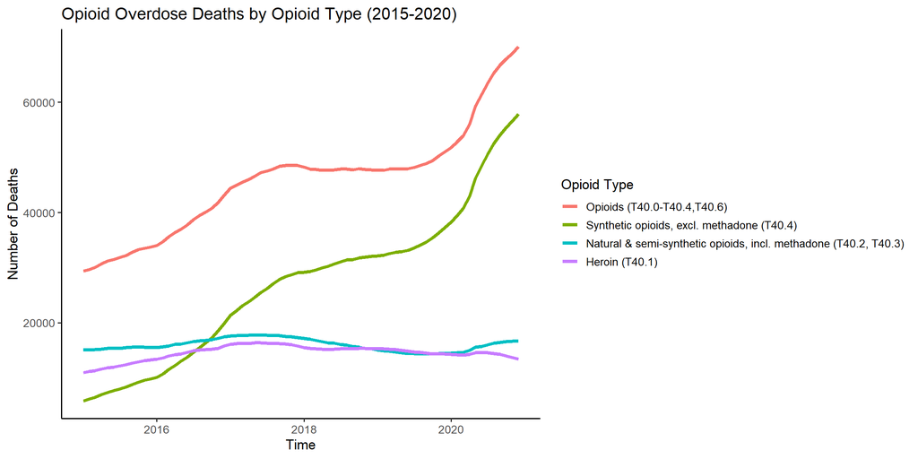

```r
# line plot for opioid deaths overall and by type
vsrr.us.plot <- vsrr.us %>%
  filter(Year <= 2020) %>%
  select(Time, Indicator, Predicted.Value) %>%
  mutate(`Number of Deaths` = as.numeric(gsub(",", "", Predicted.Value))) %>%
  arrange(desc(Time), Indicator) %>%
  rename("Opioid Type" = "Indicator") %>%
  mutate(`Opioid Type` = factor(`Opioid Type`,
                                levels = c("Opioids (T40.0-T40.4,T40.6)",
                                 "Synthetic opioids, excl. methadone (T40.4)",
                                 "Natural & semi-synthetic opioids, incl. methadone (T40.2, T40.3)",
                                 "Heroin (T40.1)")))

ggplot(vsrr.us.plot, aes(x=Time, y=`Number of Deaths`, colour=`Opioid Type`)) +
  geom_line(size=1.5) + theme_classic(base_size=13) +
  labs(title = "Opioid Overdose Deaths by Opioid Type (2015-2020)")
```

## Prescription Opioid Dispensing Rates

```r
# number and percent of counties with dispensing rate >100 prescriptions per 100 residents in 2015
county.disp.map %>%
  summarize(Data2015_Available = sum(!is.na(disp.rate.2015)),
            Counties2015_GT_100 = sum(disp.rate.2015.gt100, na.rm = TRUE),
            Per_Counties2015_GT_100 = round(100 * mean(disp.rate.2015.gt100, na.rm = TRUE), 2))
```

```
##   Data2015_Available Counties2015_GT_100 Per_Counties2015_GT_100
## 1               2938                 855                    29.1
```

```r
# 20 counties with highest dispensing rates in 2015
county.disp.map %>%
  select(county, state, disp.rate.2015) %>%
  arrange(-disp.rate.2015) %>%
  slice(1:20)
```

```
##                   county state disp.rate.2015
## 1            NORTON CITY    VA          504.9
## 2      MARTINSVILLE CITY    VA          444.4
## 3             GALAX CITY    VA          431.1
## 4           EMPORIA CITY    VA          300.6
## 5          FRANKLIN CITY    VA          271.8
## 6         LEXINGTON CITY    VA          269.0
## 7                WHITLEY    KY          265.2
## 8         COVINGTON CITY    VA          256.4
## 9                   BELL    KY          252.7
## 10                WALKER    AL          249.9
## 11                OWSLEY    KY          249.7
## 12                 FLOYD    KY          245.0
## 13                HARDIN    IL          243.4
## 14 COLONIAL HEIGHTS CITY    VA          243.0
## 15                  PIKE    KY          242.4
## 16       WAYNESBORO CITY    VA          232.1
## 17              CAMPBELL    TN          228.1
## 18               COLBERT    AL          222.9
## 19              FRANKLIN    AL          222.4
## 20                  CLAY    KY          220.9
```

```r
# number and percent of counties with dispensing rate >100 prescriptions per 100 residents in 2020
county.disp.map %>%
  summarize(Data2020_Available = sum(!is.na(disp.rate.2020)),
            Counties2020_GT_100 = sum(disp.rate.2020.gt100, na.rm = TRUE),
            Per_Counties2020_GT_100 = round(100 * mean(disp.rate.2020.gt100, na.rm = TRUE), 2))
```

```
##   Data2020_Available Counties2020_GT_100 Per_Counties2020_GT_100
## 1               3049                 112                    3.67
```

```r
# counties with highest dispensing rates in 2020
county.disp.map %>%
  select(county, state, disp.rate.2020) %>%
  arrange(-disp.rate.2020) %>%
  slice(1:20)
```

```
##                  county state disp.rate.2020
## 1           NORTON CITY    VA          406.7
## 2            SALEM CITY    VA          375.6
## 3     MARTINSVILLE CITY    VA          343.7
## 4                 PERRY    KY          316.5
## 5               MONTOUR    PA          260.7
## 6             MCCRACKEN    KY          244.4
## 7                 UNION    SD          233.8
## 8   FREDERICKSBURG CITY    VA          220.4
## 9       WINCHESTER CITY    VA          219.0
## 10               HARPER    OK          205.1
## 11              FORREST    MS          193.8
## 12               OWSLEY    KY          192.2
## 13                CLARK    KY          188.1
## 14                 TIFT    GA          181.6
## 15               HARMON    OK          171.3
## 16            CRAIGHEAD    AR          164.0
## 17                 WARE    GA          160.1
## 18               HARDIN    IL          159.5
## 19           LAUDERDALE    MS          157.7
## 20 CHARLOTTESVILLE CITY    VA          153.8
```

The substantial reduction in prescription opioid dispensing rates over time is evident from choropleth maps by county for each year between 2015 and 2020. In 2015, the highest rates of prescription opioid dispensing were observed in the Southeast and the Northwest. While the overall downward trend in opioid dispensing is evident every year, the most substantial year-over-year change appeared to occur between 2018 and 2019, particularly in the Southeast US. Nonetheless, in 2020, most counties with high prescription opioid dispensing rates remained in the Southeast.

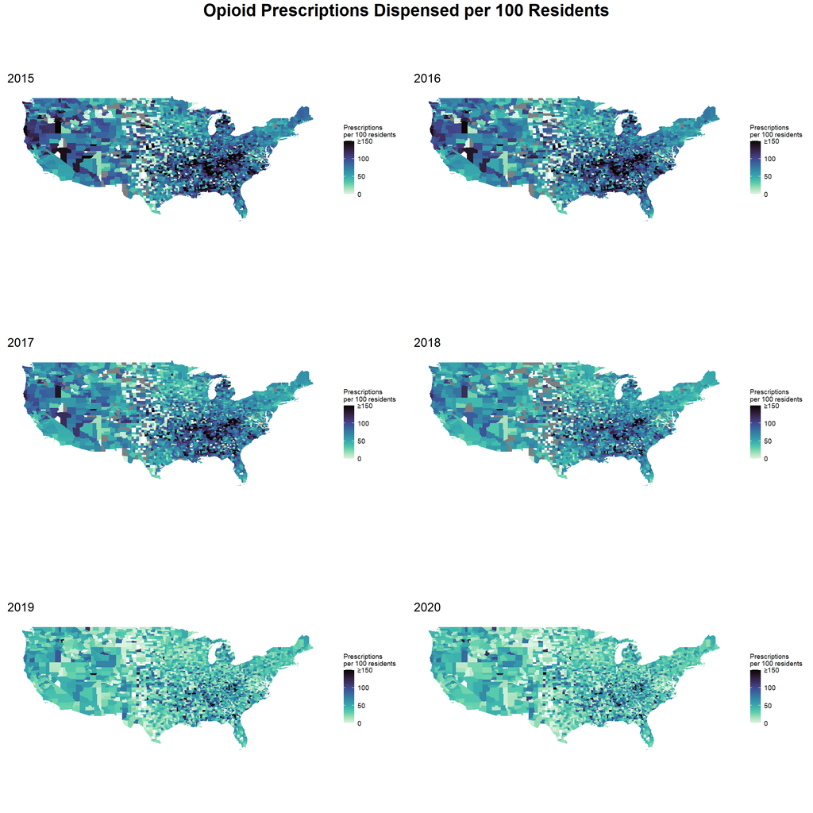

```r
# color palette and theme elements
myPalette <- colorRampPalette(brewer.pal(6, "Blues"))
my_theme <- function() {
  theme_minimal() +
  theme(axis.line = element_blank(),
        axis.text = element_blank(),
        axis.title = element_blank(),
        panel.grid = element_line(color = "white"),
        legend.key.size = unit(0.4, "cm"),
        legend.text = element_text(size = 12),
        legend.title = element_text(size = 12))
}

# choropleth map of opioid dispensing rates (2015)
disp.2015 <- ggplot() +
  geom_sf(data = county.disp.map, aes(geometry = geometry, fill = disp.rate.2015.trunc), lty=0) +
  my_theme() +
  ggtitle("2015") +
  scale_fill_viridis(name = "Prescriptions \nper 100 residents",
                     labels = c("0", "50", "100", "≥150"),
                     breaks = c(0, 50, 100, 150), option = "mako", direction = -1) +
  theme(legend.title = element_text(size = 7),
               legend.text = element_text(size = 7))

# choropleth map of opioid dispensing rates (2016)
disp.2016 <- ggplot() +
  geom_sf(data = county.disp.map, aes(geometry = geometry, fill = disp.rate.2016.trunc), lty=0) +
  my_theme() +
  ggtitle("2016") +
  scale_fill_viridis(name = "Prescriptions \nper 100 residents",
                     labels = c("0", "50", "100", "≥150"),
                     breaks = c(0, 50, 100, 150), option = "mako", direction = -1) +
  theme(legend.title = element_text(size = 7),
               legend.text = element_text(size = 7))

# choropleth map of opioid dispensing rates (2017)
disp.2017 <- ggplot() +
  geom_sf(data = county.disp.map, aes(geometry = geometry, fill = disp.rate.2017.trunc), lty=0) +
  my_theme() +
  ggtitle("2017") +
  scale_fill_viridis(name = "Prescriptions \nper 100 residents",
                     labels = c("0", "50", "100", "≥150"),
                     breaks = c(0, 50, 100, 150), option = "mako", direction = -1) +
  theme(legend.title = element_text(size = 7),
               legend.text = element_text(size = 7))

# choropleth map of opioid dispensing rates (2018)
disp.2018 <- ggplot() +
  geom_sf(data = county.disp.map, aes(geometry = geometry, fill = disp.rate.2018.trunc), lty=0) +
  my_theme() +
  ggtitle("2018") +
  scale_fill_viridis(name = "Prescriptions \nper 100 residents",
                     labels = c("0", "50", "100", "≥150"),
                     breaks = c(0, 50, 100, 150), option = "mako", direction = -1) +
  theme(legend.title = element_text(size = 7),
               legend.text = element_text(size = 7))

# choropleth map of opioid dispensing rates (2019)
disp.2019 <- ggplot() +
  geom_sf(data = county.disp.map, aes(geometry = geometry, fill = disp.rate.2019.trunc), lty=0) +
  my_theme() +
  ggtitle("2019") +
  scale_fill_viridis(name = "Prescriptions \nper 100 residents",
                     labels = c("0", "50", "100", "≥150"),
                     breaks = c(0, 50, 100, 150), option = "mako", direction = -1) +
  theme(legend.title = element_text(size = 7),
               legend.text = element_text(size = 7))

# choropleth map of opioid dispensing rates (2020)
disp.2020 <- ggplot() +
  geom_sf(data = county.disp.map, aes(geometry = geometry, fill = disp.rate.2020.trunc), lty=0) +
  my_theme() +
  ggtitle("2020") +
  scale_fill_viridis(name = "Prescriptions \nper 100 residents",
                     labels = c("0", "50", "100", "≥150"),
                     breaks = c(0, 50, 100, 150), option = "mako", direction = -1) +
  theme(legend.title = element_text(size = 7),
               legend.text = element_text(size = 7))

# display opioid prescribing rate maps (2015-2020) in a grid
grid.arrange(disp.2015, disp.2016, disp.2017, disp.2018, disp.2019, disp.2020,
             top = textGrob("Opioid Prescriptions Dispensed per 100 Residents",
             gp = gpar(fontsize=18, font=2)))
```

## Relative Changes in Prescription Opioid Dispensing

Nationally, 89.6% of the counties in the United States with available data reported a decrease in prescription opioid dispensing from 2015 to 2020. At the county level, the median decrease in the rate of prescription opioids dispensed was 53.2% (interquartile range, 33.8% to 67.2%).

```r
# percent of counties reporting a decrease in opioid prescribing from 2015 to 2020
county.disp.map %>%
  mutate(disp.dec = ifelse(perc.chg.15.20 < 0, 1, 0)) %>%
  summarise(`% Counties Decrease in Rate` = 100 * mean(disp.dec, na.rm = TRUE))
```

```
##   % Counties Decrease in Rate
## 1                    89.58475
```

```r
# median and IQR of percent change in prescribing from 2015 to 2020
quantile(county.disp.map$perc.chg.15.20, probs = c(0.1, 0.25, 0.5, 0.75, 0.9), na.rm = TRUE)
```

```
##        10%        25%        50%        75%        90%
## -78.726147 -67.194494 -53.193152 -33.779215   2.729369
```

While the vast preponderance of counties reported a decline in prescription opioid dispensing from 2015 to 2020, the magnitude of change was variable across the country.

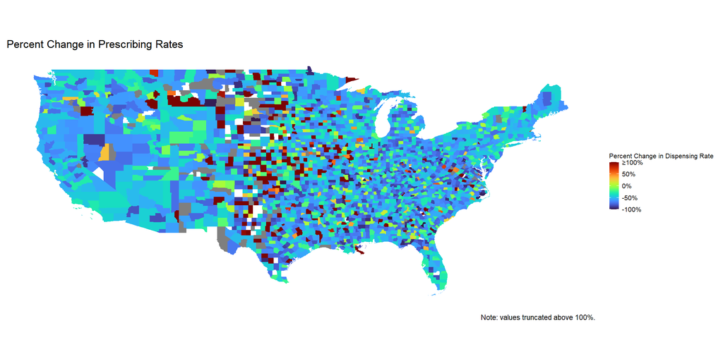

```r
# color palette and theme elements
myPalette <- colorRampPalette(brewer.pal(6, "Blues"))
my_theme <- function() {
  theme_minimal() +
  theme(axis.line = element_blank(),
        axis.text = element_blank(),
        axis.title = element_blank(),
        panel.grid = element_line(color = "white"),
        legend.key.size = unit(0.4, "cm"),
        legend.text = element_text(size = 12),
        legend.title = element_text(size = 12))
}

# choropleth map of percent change in opioid prescribing rates (2015 to 2020)
ggplot() +
  geom_sf(data = county.disp.map, aes(geometry = geometry, fill = perc.chg.15.20.trunc), lty=0) +
  my_theme() +
  ggtitle("Percent Change in Prescribing Rates") +
  scale_fill_viridis(name = "Percent Change in Dispensing Rate",
                    labels = c("-100%", "-50%", "0%", "50%", "≥100%"),
                    breaks = c(-100, -50, 0, 50, 100), option = "turbo") +
  labs(caption = "Note: values truncated above 100%.") +
  theme(legend.title = element_text(size = 8),
               legend.text = element_text(size = 8))
```

```r
# summary of counties with higher percent change in dispensing rates from 2015 to 2020
county.disp.map %>%
  select(county, state, disp.rate.2015, disp.rate.2020, perc.chg.15.20) %>%
  arrange(-perc.chg.15.20) %>%
  slice(1:20)
```

```
##       county state disp.rate.2015 disp.rate.2020 perc.chg.15.20
## 1       PARK    CO            0.0            0.7            Inf
## 2       LONG    GA            0.0            0.2            Inf
## 3    JERAULD    SD            0.2          108.1      53950.000
## 4  BON HOMME    SD            0.1           12.6      12500.000
## 5      CLARK    SD            0.2           15.2       7500.000
## 6      FAULK    SD            0.3           22.1       7266.667
## 7    STANTON    KS            1.5          105.8       6953.333
## 8  LAFAYETTE    AR            1.7           91.5       5282.353
## 9   CRAWFORD    GA            0.9           48.3       5266.667
## 10   HANCOCK    IA            0.6           29.7       4850.000
## 11    TOWNER    ND            0.3           14.0       4566.667
## 12    GRIGGS    ND            0.2            8.5       4150.000
## 13      OHIO    IN            1.8           53.3       2861.111
## 14     BRULE    SD            1.9           52.1       2642.105
## 15 JEFFERSON    MS            0.1            2.7       2600.000
## 16 DICKINSON    KS            1.9           48.7       2463.158
## 17   JACKSON    MN            0.6           14.9       2383.333
## 18     WELLS    ND            2.1           51.3       2342.857
## 19   LINCOLN    GA            2.7           65.1       2311.111
## 20 VAN BUREN    IA            1.6           37.7       2256.250
```

## Drug Overdose Death Rates

```r
# percent of counties with drug overdose death rate >50 per 100,000 in 2015
nchs.map %>%
  filter(Year==2015) %>%
  mutate(deathrate.gt50 = ifelse(Model.based.Death.Rate > 50, 1, 0)) %>%
  summarise(Data2015_Available = sum(!is.na(Model.based.Death.Rate)),
            `N Counties Death Rate >=50` = sum(deathrate.gt50, na.rm = TRUE),
            `% Counties Death Rate >=50` = 100 * mean(deathrate.gt50, na.rm = TRUE))
```

```
##   Data2015_Available N Counties Death Rate >=50 % Counties Death Rate >=50
## 1               3136                         18                  0.5739796
```

```r
# counties with highest drug overdose death rates in 2015
nchs.map %>%
  filter(Year==2015) %>%
  select(County, Model.based.Death.Rate, 2) %>%
  arrange(-Model.based.Death.Rate) %>%
  slice(1:20)
```

```
##                   County Model.based.Death.Rate Year
## 1    McDowell County, WV              113.94030 2015
## 2     Wyoming County, WV               94.70004 2015
## 3      Cabell County, WV               76.59532 2015
## 4        Bell County, KY               74.06371 2015
## 5     Raleigh County, WV               73.09368 2015
## 6  Rio Arriba County, NM               70.37913 2015
## 7       Boone County, WV               69.20609 2015
## 8      Kenton County, KY               65.22537 2015
## 9       Logan County, WV               62.97285 2015
## 10     Martin County, KY               58.59269 2015
## 11     Mercer County, WV               56.89083 2015
## 12      Mingo County, WV               54.89322 2015
## 13    Kanawha County, WV               54.84640 2015
## 14     Powell County, KY               53.76168 2015
## 15   Gallatin County, KY               52.69795 2015
## 16    Baltimore city, MD               52.06326 2015
## 17      Clark County, OH               51.00312 2015
## 18     Butler County, OH               50.38959 2015
## 19      Floyd County, KY               49.88961 2015
## 20    Clinton County, KY               49.77771 2015
```

```r
# percent of counties with drug overdose death rate >50 per 100,000 in 2020
nchs.map %>%
  filter(Year==2020) %>%
  mutate(deathrate.gt50 = ifelse(Model.based.Death.Rate > 50, 1, 0)) %>%
  summarise(Data2015_Available = sum(!is.na(Model.based.Death.Rate)),
            `N Counties Death Rate >=50` = sum(deathrate.gt50, na.rm = TRUE),
            `% Counties Death Rate >=50` = 100 * mean(deathrate.gt50, na.rm = TRUE))
```

```
##   Data2015_Available N Counties Death Rate >=50 % Counties Death Rate >=50
## 1               3136                        166                   5.293367
```

```r
# counties with highest drug overdose death rates in 2020
nchs.map %>%
  filter(Year==2020) %>%
  select(County, Model.based.Death.Rate, 2) %>%
  arrange(-Model.based.Death.Rate) %>%
  slice(1:20)
```

```
##                   County Model.based.Death.Rate Year
## 1    McDowell County, WV              153.17750 2020
## 2     Baltimore city, MD              140.57060 2020
## 3       Logan County, WV              135.28370 2020
## 4      Scioto County, OH              128.88260 2020
## 5      Cabell County, WV              128.78410 2020
## 6     Raleigh County, WV              127.49480 2020
## 7     Wyoming County, WV              114.45080 2020
## 8       Wayne County, WV              110.39540 2020
## 9       Boone County, WV              103.64120 2020
## 10      Knott County, KY              102.32980 2020
## 11 Rio Arriba County, NM              101.33350 2020
## 12     Mercer County, WV              101.11240 2020
## 13    Summers County, WV              100.40760 2020
## 14    Kanawha County, WV               99.36386 2020
## 15    St. Louis city, MO               97.41612 2020
## 16      Mingo County, WV               91.45689 2020
## 17      Cecil County, MD               89.55744 2020
## 18      Clark County, KY               86.20066 2020
## 19   Berkeley County, WV               86.01582 2020
## 20      Scott County, IN               85.87272 2020
```

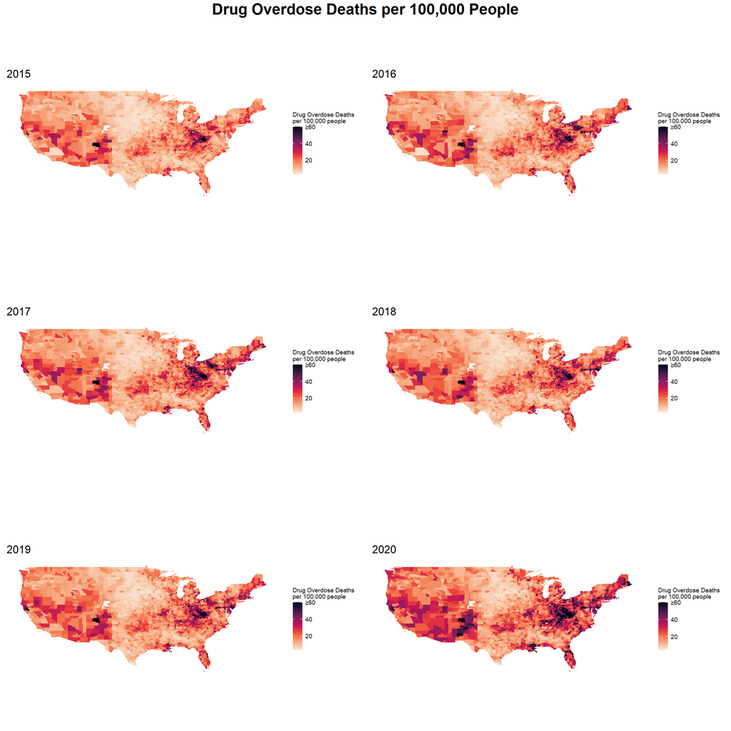

```r
# choropleth map of drug overdose death rates (2015)
od.2015 <- ggplot() +
  geom_sf(data = subset(nchs.map, Year==2015),
          aes(geometry = geometry, fill = deathrate.trunc), lty=0) +
  my_theme() +
  ggtitle("2015") +
  scale_fill_viridis(name = "Drug Overdose Deaths \nper 100,000 people",
                    labels = c("0", "20", "40", "≥60"),
                    breaks = c(0, 20, 40, 60), option = "rocket", direction = -1) +
  theme(legend.title = element_text(size = 7),
               legend.text = element_text(size = 7))

# choropleth map of drug overdose death rates (2016)
od.2016 <- ggplot() +
  geom_sf(data = subset(nchs.map, Year==2016),
          aes(geometry = geometry, fill = deathrate.trunc), lty=0) +
  my_theme() +
  ggtitle("2016") +
  scale_fill_viridis(name = "Drug Overdose Deaths \nper 100,000 people",
                    labels = c("0", "20", "40", "≥60"),
                    breaks = c(0, 20, 40, 60), option = "rocket", direction = -1) +
  theme(legend.title = element_text(size = 7),
               legend.text = element_text(size = 7))

# choropleth map of drug overdose death rates (2017)
od.2017 <- ggplot() +
  geom_sf(data = subset(nchs.map, Year==2017),
          aes(geometry = geometry, fill = deathrate.trunc), lty=0) +
  my_theme() +
  ggtitle("2017") +
  scale_fill_viridis(name = "Drug Overdose Deaths \nper 100,000 people",
                    labels = c("0", "20", "40", "≥60"),
                    breaks = c(0, 20, 40, 60), option = "rocket", direction = -1) +
  theme(legend.title = element_text(size = 7),
               legend.text = element_text(size = 7))

# choropleth map of drug overdose death rates (2018)
od.2018 <- ggplot() +
  geom_sf(data = subset(nchs.map, Year==2018),
          aes(geometry = geometry, fill = deathrate.trunc), lty=0) +
  my_theme() +
  ggtitle("2018") +
  scale_fill_viridis(name = "Drug Overdose Deaths \nper 100,000 people",
                    labels = c("0", "20", "40", "≥60"),
                    breaks = c(0, 20, 40, 60), option = "rocket", direction = -1) +
  theme(legend.title = element_text(size = 7),
               legend.text = element_text(size = 7))

# choropleth map of drug overdose death rates (2019)
od.2019 <- ggplot() +
  geom_sf(data = subset(nchs.map, Year==2019),
          aes(geometry = geometry, fill = deathrate.trunc), lty=0) +
  my_theme() +
  ggtitle("2019") +
  scale_fill_viridis(name = "Drug Overdose Deaths \nper 100,000 people",
                    labels = c("0", "20", "40", "≥60"),
                    breaks = c(0, 20, 40, 60), option = "rocket", direction = -1) +
  theme(legend.title = element_text(size = 7),
               legend.text = element_text(size = 7))

# choropleth map of drug overdose death rates (2020)
od.2020 <- ggplot() +
  geom_sf(data = subset(nchs.map, Year==2020),
          aes(geometry = geometry, fill = deathrate.trunc), lty=0) +
  my_theme() +
  ggtitle("2020") +
  scale_fill_viridis(name = "Drug Overdose Deaths \nper 100,000 people",
                    labels = c("0", "20", "40", "≥60"),
                    breaks = c(0, 20, 40, 60), option = "rocket", direction = -1) +
  theme(legend.title = element_text(size = 7),
               legend.text = element_text(size = 7))

# display drug overdose death rate maps (2015-2020) in a grid
grid.arrange(od.2015, od.2016, od.2017, od.2018, od.2019, od.2020,
             top = textGrob("Drug Overdose Deaths per 100,000 People",
             gp = gpar(fontsize=18, font=2)))
```

## Predictors of Drug Overdose Death Rate

### Bivariate Analyses

The distribution of the county-level drug overdose death rates was highly right-skewed, which violates a key assumption of linear models. A log transformation of the drug overdose death rate normalized the distribution to facilitate linear modeling.

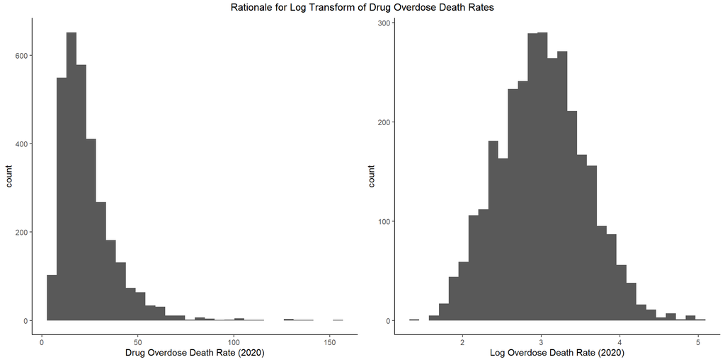

```r
# histogram of non-transformed drug overdose death rate (2020)
hist.death.rate <- ggplot(risk.data, aes(x=Model.based.Death.Rate)) + geom_histogram() + theme_classic() +
  scale_x_continuous(name = "Drug Overdose Death Rate (2020)")

# histogram of log-transformed drug overdose death rate (2020)
hist.log.death.rate <- ggplot(risk.data, aes(x=logdeathrate)) + geom_histogram() + theme_classic() +
  scale_x_continuous(name = "Log Overdose Death Rate (2020)")

# display 1x2 grid of histograms of non- and log-transformed drug overdose death rates
grid.arrange(hist.death.rate, hist.log.death.rate, ncol=2, heights=5,
             top = textGrob("Rationale for Log Transform of Drug Overdose Death Rates"))
```

There was a general increasing trend with higher prescription opioid prescribing associated with higher drug overdose death rates.

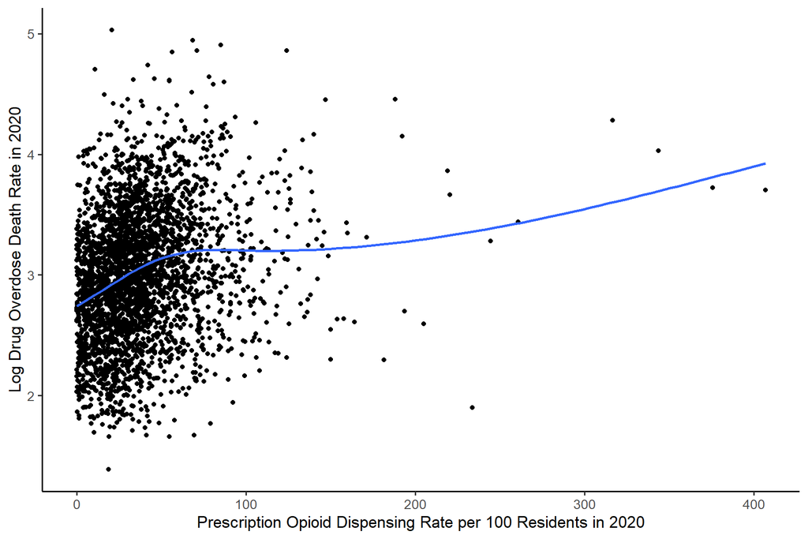

```r
# scatterplot of log drug overdose death rate on prescription opioid dispensing rate with loess line
ggplot(risk.data, aes(disp.rate.2020, logdeathrate)) +
  geom_point() + xlab("Prescription Opioid Dispensing Rate per 100 Residents in 2020") +
  geom_smooth(se=FALSE) + ylab("Log Drug Overdose Death Rate in 2020") +
  theme_classic(base_size=13)
```

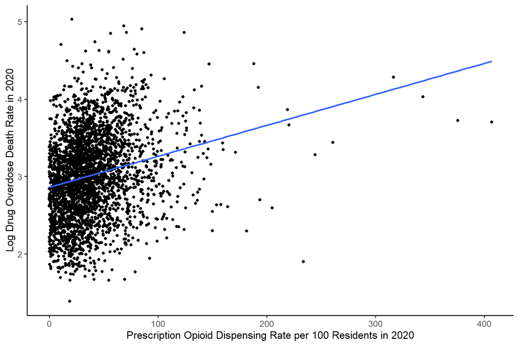

```r
# scatterplot of log drug overdose death rate on prescription opioid dispensing rate with regression line
ggplot(risk.data, aes(disp.rate.2020, logdeathrate)) +
  geom_point() + xlab("Prescription Opioid Dispensing Rate per 100 Residents in 2020") +
  geom_smooth(method='lm', se=FALSE) + ylab("Log Drug Overdose Death Rate in 2020") +
  theme_classic(base_size=13)
```

Since drug overdose deaths was log transformed, the $\beta$ coefficients from these models can be interpreted by exponentiating the coefficient estimate minus 1 times 100% (i.e., $(e^\beta - 1) * 100\%$). For this model, a 10 prescription per 100 resident increase in opioid dispensing at the county level was associated with an average $(e^.039997 - 1) * 100\% = 4.1\%$ increase in the county’s drug overdose death rate.

```r
# linear regression model of log drug overdose death rate on opioid dispensing rate in 2020
mod1 <- lm(logdeathrate ~ opioid.rx.10, data=risk.data)
summary(mod1)
```

```
##
## Call:
## lm(formula = logdeathrate ~ opioid.rx.10, data = risk.data)
##
## Residuals:
##      Min       1Q   Median       3Q      Max
## -1.89509 -0.37037 -0.00444  0.35744  2.08779
##
## Coefficients:
##              Estimate Std. Error t value Pr(>|t|)
## (Intercept)  2.861017   0.015454  185.13   <2e-16 ***
## opioid.rx.10 0.039997   0.003113   12.85   <2e-16 ***
## ---
## Signif. codes:  0 '***' 0.001 '**' 0.01 '*' 0.05 '.' 0.1 ' ' 1
##
## Residual standard error: 0.5334 on 3068 degrees of freedom
##   (73 observations deleted due to missingness)
## Multiple R-squared:  0.05106,    Adjusted R-squared:  0.05075
## F-statistic: 165.1 on 1 and 3068 DF,  p-value: < 2.2e-16
```

```r
# transform model coefficient for interpretation
100*(exp(mod1$coefficients[2]) - 1)
```

```
## opioid.rx.10
##     4.080772
```

```r
# linear regression model of log drug overdose death rate on opioid dispensing rate in 2020
mod2 <- lm(logdeathrate ~ log.opioid.rx, data=risk.data)
summary(mod2)
```

```
##
## Call:
## lm(formula = logdeathrate ~ log.opioid.rx, data = risk.data)
##
## Residuals:
##      Min       1Q   Median       3Q      Max
## -1.58024 -0.36797 -0.00376  0.35899  2.05280
##
## Coefficients:
##               Estimate Std. Error t value Pr(>|t|)
## (Intercept)    2.57781    0.03372   76.44   <2e-16 ***
## log.opioid.rx  0.13212    0.00974   13.56   <2e-16 ***
## ---
## Signif. codes:  0 '***' 0.001 '**' 0.01 '*' 0.05 '.' 0.1 ' ' 1
##
## Residual standard error: 0.5319 on 3068 degrees of freedom
##   (73 observations deleted due to missingness)
## Multiple R-squared:  0.05658,    Adjusted R-squared:  0.05627
## F-statistic:   184 on 1 and 3068 DF,  p-value: < 2.2e-16
```

```r
# transform model coefficient for interpretation
100*(1.2^mod2$coefficients[2] - 1)
```

```
## log.opioid.rx
##      2.438108
```

Regardless of the distributional assumptions underlying the linear model, prescription opioid prescribing was positively associated with drug overdose death, predicting approximately 5% of the variance across counties.

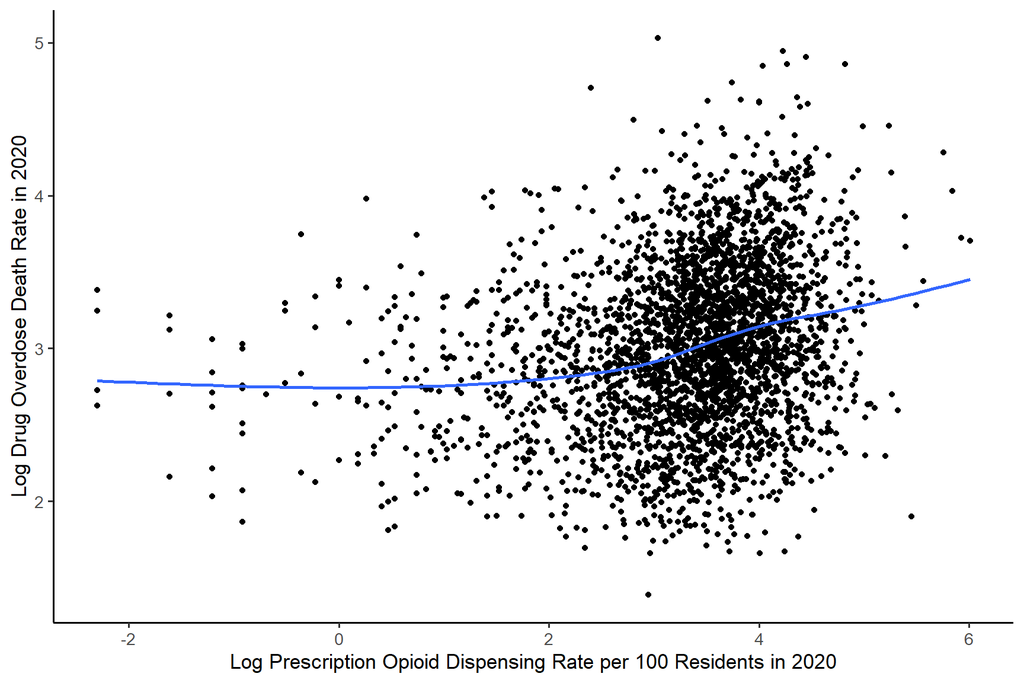

```r
# scatterplot of log drug overdose death rate on log prescription opioid dispensing rate with loess line
ggplot(risk.data, aes(log.opioid.rx, logdeathrate)) +
  geom_point() + xlab("Log Prescription Opioid Dispensing Rate per 100 Residents in 2020") +
  geom_smooth(se=FALSE) + ylab("Log Drug Overdose Death Rate in 2020") +
  theme_classic(base_size=13)
```

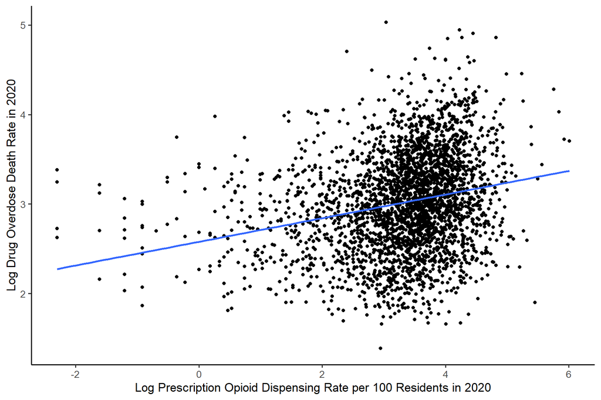

```r
# scatterplot of log drug overdose death rate on log prescription opioid dispensing rate with regression line
ggplot(risk.data, aes(log.opioid.rx, logdeathrate)) +
  geom_point() + xlab("Log Prescription Opioid Dispensing Rate per 100 Residents in 2020") +
  geom_smooth(method='lm', se=FALSE) + ylab("Log Drug Overdose Death Rate in 2020") +
  theme_classic(base_size=13)
```

The CDC PLACES dataset contains age-adjusted prevalence estimates for various indicators of health within each county. The variables of interest from the dataset were:

- **No Annual Checkup**: Proportion of adults who had a visit to a doctor for a routine checkup in the past year
- **Binge Drinking**: Proportion of adults who had 5 or more alcoholic drinks (males) or 4 or more alcoholic drinks (females) within the past 30 days
- **Current Smoking**: Proportion of adults who currently smoke some days or every day
- **Depression**: Proportion of adults who have had a depressive disorder (depression, major depression, dysthymia, or minor depression)
- **General Health**: Proportion of adults self-reporting ‘fair’ or ‘poor’ general health
- **No Health Insurance**: Proportion of adults with any kind of health care coverage, including health insurance, prepaid plans (e.g., HMOs), or government plans (e.g., Medicare, Indian Health Service)
- **Mental Health**: Proportion of adults self-reporting that their mental health was not good for at least 14 of the past 30 days
- **Obesity**: Proportion of adults with obesity (body mass index $\ge$ 30)
- **Physical Health**: Proportion of adults self-reporting that their physical health was not good for at least 14 of the past 30 days
- **Physical Inactivity**: Proportion of adults who reported doing no physical activity or exercise during the past 30 days other than their regular job

The table below provides summary statistics of the prevalence proportions for each of the health indicators.

```r
# summary table for prevalence of health indicator variables from PLACES dataset
health.summary <- risk.data %>%
  select(`No Annual Checkup`, `Binge Drinking`, `Current Smoking`, `Depression`, `General Health`,
         `No Health Insurance`, `Mental Health`, `Obesity`, `Physical Health`, `Physical Inactivity`) %>%
  tbl_summary(
    type = all_continuous() ~ "continuous2",
    statistic = all_continuous() ~ c("{mean} ({sd})",
                                     "{median} ({p25}, {p75})",
                                     "{min}, {max}"),
    missing = "no") %>%
  modify_caption("**Summary Statistics of County-Level Prevalence (%) of Health Indicators**") %>%
  bold_labels()

# apply kable styles to summary table
as_kable_extra(health.summary, format = "html", table.attr = "style='width:50%;'") %>%
  kable_styling(position = "left", htmltable_class = "lightable-classic")
```

**Summary Statistics of County-Level Prevalence (%) of Health Indicators**

| Characteristic | N = 3,143 |
| --- | --- |
| No Annual Checkup |  |
| Mean (SD) | 27.2 (4.0) |
| Median (IQR) | 26.8 (24.4, 30.2) |
| Range | 17.4, 41.7 |
| Binge Drinking |  |
| Mean (SD) | 17.84 (3.02) |
| Median (IQR) | 17.60 (15.70, 19.70) |
| Range | 8.20, 27.60 |
| Current Smoking |  |
| Mean (SD) | 20.0 (4.1) |
| Median (IQR) | 19.9 (17.5, 22.6) |
| Range | 5.8, 41.1 |
| Depression |  |
| Mean (SD) | 21.9 (3.2) |
| Median (IQR) | 21.8 (19.4, 24.1) |
| Range | 10.7, 31.9 |
| General Health |  |
| Mean (SD) | 16.0 (4.4) |
| Median (IQR) | 15.3 (12.6, 19.0) |
| Range | 6.5, 36.8 |
| No Health Insurance |  |
| Mean (SD) | 16.8 (6.6) |
| Median (IQR) | 15.0 (12.1, 19.5) |
| Range | 5.7, 53.3 |
| Mental Health |  |
| Mean (SD) | 15.73 (2.04) |
| Median (IQR) | 15.70 (14.30, 17.20) |
| Range | 8.30, 23.30 |
| Obesity |  |
| Mean (SD) | 36.2 (4.7) |
| Median (IQR) | 36.7 (33.7, 39.2) |
| Range | 17.6, 53.2 |
| Physical Health |  |
| Mean (SD) | 10.96 (2.15) |
| Median (IQR) | 10.80 (9.30, 12.40) |
| Range | 5.60, 20.90 |
| Physical Inactivity |  |
| Mean (SD) | 25.7 (5.2) |
| Median (IQR) | 25.2 (22.0, 29.2) |
| Range | 10.2, 47.2 |

Since there was a potential that the predictor variables to be correlated, a correlation matrix was generated to avoid introducing multicollinearity into multivariable models. The variables that tended to have the highest correlations with other variables were *General Health*, *Physical Health*, *Current Smoking*, and *Mental Health*.

```r
# select variables for correlation matrix
cor.predictors <- risk.data %>%
  select(c("disp.rate.2020", "No Annual Checkup", "General Health", "Depression", "No Health Insurance",
           "Obesity", "Binge Drinking", "Physical Health", "Current Smoking", "Physical Inactivity",
           "Mental Health"))

# correlation matrix of predictor variables
cor.matrix <- cor(cor.predictors, method = "pearson", use = "complete.obs")
round(cor.matrix, 2)
```

```
##                     disp.rate.2020 No Annual Checkup General Health Depression
## disp.rate.2020                1.00             -0.19           0.07       0.15
## No Annual Checkup            -0.19              1.00          -0.32      -0.26
## General Health                0.07             -0.32           1.00       0.46
## Depression                    0.15             -0.26           0.46       1.00
## No Health Insurance          -0.06              0.04           0.63       0.04
## Obesity                       0.06             -0.42           0.73       0.34
## Binge Drinking               -0.19              0.43          -0.57      -0.32
## Physical Health               0.08             -0.27           0.95       0.60
## Current Smoking               0.04             -0.34           0.74       0.60
## Physical Inactivity           0.07             -0.40           0.93       0.39
## Mental Health                 0.13             -0.35           0.77       0.82
##                     No Health Insurance Obesity Binge Drinking Physical Health
## disp.rate.2020                    -0.06    0.06          -0.19            0.08
## No Annual Checkup                  0.04   -0.42           0.43           -0.27
## General Health                     0.63    0.73          -0.57            0.95
## Depression                         0.04    0.34          -0.32            0.60
## No Health Insurance                1.00    0.39          -0.33            0.51
## Obesity                            0.39    1.00          -0.31            0.67
## Binge Drinking                    -0.33   -0.31           1.00           -0.50
## Physical Health                    0.51    0.67          -0.50            1.00
## Current Smoking                    0.23    0.71          -0.28            0.82
## Physical Inactivity                0.57    0.79          -0.50            0.88
## Mental Health                      0.26    0.55          -0.46            0.86
##                     Current Smoking Physical Inactivity Mental Health
## disp.rate.2020                 0.04                0.07          0.13
## No Annual Checkup             -0.34               -0.40         -0.35
## General Health                 0.74                0.93          0.77
## Depression                     0.60                0.39          0.82
## No Health Insurance            0.23                0.57          0.26
## Obesity                        0.71                0.79          0.55
## Binge Drinking                -0.28               -0.50         -0.46
## Physical Health                0.82                0.88          0.86
## Current Smoking                1.00                0.78          0.77
## Physical Inactivity            0.78                1.00          0.70
## Mental Health                  0.77                0.70          1.00
```

Scatterplots were generated to evaluate the bivariate relationship between health indicators and log drug overdose death rates. Higher county-level prevalence estimates of depression, poor general health, poor physical health, current smoking, physical inactivity, and poor mental health were associated with higher drug overdose death rates. Counterintuitively, the prevalences of no annual checkup, no health insurance, obesity, and binge drinking were inversely related to the drug overdose death rate.

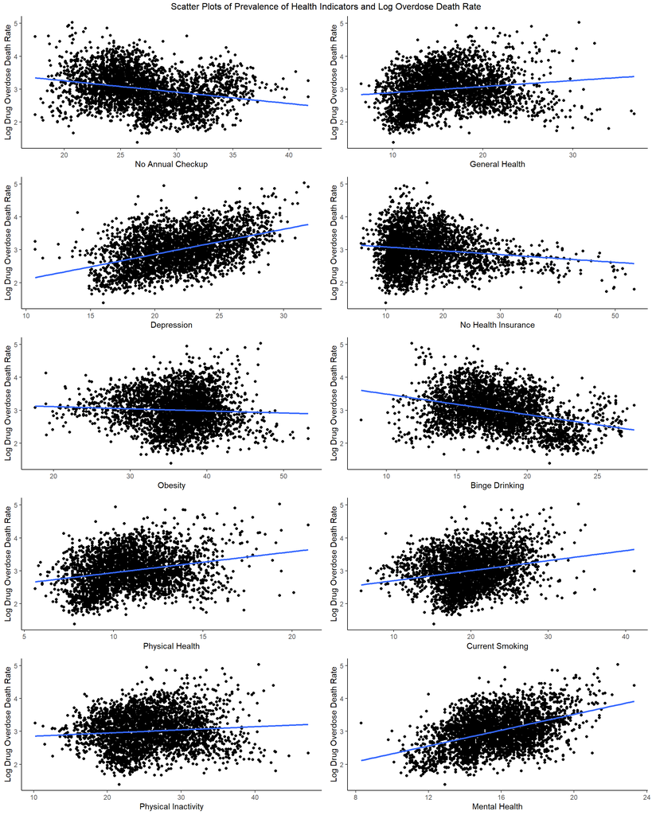

```r
# scatterplots on log drug overdose rate for each respective health indicator
plot.nc <- ggplot(risk.data, aes(`No Annual Checkup`, logdeathrate)) +
  geom_point() +  geom_smooth(method='lm', se=FALSE) + theme_classic() +
  ylab("Log Drug Overdose Death Rate")

plot.gh <- ggplot(risk.data, aes(`General Health`, logdeathrate)) +
  geom_point() +  geom_smooth(method='lm', se=FALSE) + theme_classic() +
  ylab("Log Drug Overdose Death Rate")

plot.dp <- ggplot(risk.data, aes(`Depression`, logdeathrate)) +
  geom_point() +  geom_smooth(method='lm', se=FALSE) + theme_classic() +
  ylab("Log Drug Overdose Death Rate")

plot.in <- ggplot(risk.data, aes(`No Health Insurance`, logdeathrate)) +
  geom_point() +  geom_smooth(method='lm', se=FALSE) + theme_classic() +
  ylab("Log Drug Overdose Death Rate")

plot.ob <- ggplot(risk.data, aes(`Obesity`, logdeathrate)) +
  geom_point() +  geom_smooth(method='lm', se=FALSE) + theme_classic() +
  ylab("Log Drug Overdose Death Rate")

plot.bd <- ggplot(risk.data, aes(`Binge Drinking`, logdeathrate)) +
  geom_point() +  geom_smooth(method='lm', se=FALSE) + theme_classic() +
  ylab("Log Drug Overdose Death Rate")

plot.ph <- ggplot(risk.data, aes(`Physical Health`, logdeathrate)) +
  geom_point() +  geom_smooth(method='lm', se=FALSE) + theme_classic() +
  ylab("Log Drug Overdose Death Rate")

plot.cs <- ggplot(risk.data, aes(`Current Smoking`, logdeathrate)) +
  geom_point() +  geom_smooth(method='lm', se=FALSE) + theme_classic() +
  ylab("Log Drug Overdose Death Rate")

plot.pi <- ggplot(risk.data, aes(`Physical Inactivity`, logdeathrate)) +
  geom_point() +  geom_smooth(method='lm', se=FALSE) + theme_classic() +
  ylab("Log Drug Overdose Death Rate")

plot.mh <- ggplot(risk.data, aes(`Mental Health`, logdeathrate)) +
  geom_point() +  geom_smooth(method='lm', se=FALSE) + theme_classic() +
  ylab("Log Drug Overdose Death Rate")

# display grid of scatterplots of log drug overdose rate on prevalence of health indicators
grid.arrange(plot.nc, plot.gh, plot.dp, plot.in, plot.ob, plot.bd, plot.ph, plot.cs,
             plot.pi, plot.mh, ncol=2, heights=c(10, 10, 10, 10, 10),
  top = textGrob("Scatter Plots of Prevalence of Health Indicators and Log Overdose Death Rate"))
```

To facilitate interpretability, all variables were scaled to represent 5 percentage-point increases in county-level prevalence in all models. The prevalence of health indicators that predicted the greatest amount of variance in univariable linear regression models were *Depression* (R<sup>2</sup>=20.3%), *Mental Health* (R<sup>2</sup>=19.9%), *Binge Drinking* (R<sup>2</sup>=11.7%), *No Annual Checkup* (R<sup>2</sup>=6.4%), *Poor Physical Health* (R<sup>2</sup>=6.2%), and *Current Smoking* (R<sup>2</sup>=5.1%). As previously noted, *Binge Drinking* and *No Annual Checkup* were surprisingly inversely associated with the overdose death rate.

```r
# linear regression models for individual predictors
lm.nc <- lm(logdeathrate ~ no.checkup.5, data=risk.data)
summary(lm.nc)
```

```
##
## Call:
## lm(formula = logdeathrate ~ no.checkup.5, data = risk.data)
##
## Residuals:
##      Min       1Q   Median       3Q      Max
## -1.64596 -0.37195 -0.01006  0.36317  1.79840
##
## Coefficients:
##              Estimate Std. Error t value Pr(>|t|)
## (Intercept)   3.94929    0.06513   60.63   <2e-16 ***
## no.checkup.5 -0.17297    0.01185  -14.60   <2e-16 ***
## ---
## Signif. codes:  0 '***' 0.001 '**' 0.01 '*' 0.05 '.' 0.1 ' ' 1
##
## Residual standard error: 0.5302 on 3128 degrees of freedom
##   (13 observations deleted due to missingness)
## Multiple R-squared:  0.06381,    Adjusted R-squared:  0.06351
## F-statistic: 213.2 on 1 and 3128 DF,  p-value: < 2.2e-16
```

```r
100*(exp(lm.nc$coefficients[2]) - 1)
```

```
## no.checkup.5
##    -15.88377
```

```r
lm.gh <- lm(logdeathrate ~ poor.gen.health.5, data=risk.data)
summary(lm.gh)
```

```
##
## Call:
## lm(formula = logdeathrate ~ poor.gen.health.5, data = risk.data)
##
## Residuals:
##      Min       1Q   Median       3Q      Max
## -1.53366 -0.38806 -0.00745  0.36792  1.91791
##
## Coefficients:
##                   Estimate Std. Error t value Pr(>|t|)
## (Intercept)        2.71559    0.03642   74.57   <2e-16 ***
## poor.gen.health.5  0.09129    0.01095    8.34   <2e-16 ***
## ---
## Signif. codes:  0 '***' 0.001 '**' 0.01 '*' 0.05 '.' 0.1 ' ' 1
##
## Residual standard error: 0.542 on 3128 degrees of freedom
##   (13 observations deleted due to missingness)
## Multiple R-squared:  0.02175,    Adjusted R-squared:  0.02144
## F-statistic: 69.56 on 1 and 3128 DF,  p-value: < 2.2e-16
```

```r
100*(exp(lm.gh$coefficients[2]) - 1)
```

```
## poor.gen.health.5
##          9.558469
```

```r
lm.dp <- lm(logdeathrate ~ depression.5, data=risk.data)
summary(lm.dp)
```

```
##
## Call:
## lm(formula = logdeathrate ~ depression.5, data = risk.data)
##
## Residuals:
##      Min       1Q   Median       3Q      Max
## -1.26221 -0.36759 -0.02799  0.34210  2.02849
##
## Coefficients:
##              Estimate Std. Error t value Pr(>|t|)
## (Intercept)   1.34079    0.05977   22.43   <2e-16 ***
## depression.5  0.38078    0.01350   28.20   <2e-16 ***
## ---
## Signif. codes:  0 '***' 0.001 '**' 0.01 '*' 0.05 '.' 0.1 ' ' 1
##
## Residual standard error: 0.4893 on 3128 degrees of freedom
##   (13 observations deleted due to missingness)
## Multiple R-squared:  0.2027, Adjusted R-squared:  0.2025
## F-statistic: 795.3 on 1 and 3128 DF,  p-value: < 2.2e-16
```

```r
100*(exp(lm.dp$coefficients[2]) - 1)
```

```
## depression.5
##     46.34272
```

```r
lm.in <- lm(logdeathrate ~ no.insurance.5, data=risk.data)
summary(lm.in)
```

```
##
## Call:
## lm(formula = logdeathrate ~ no.insurance.5, data = risk.data)
##
## Residuals:
##      Min       1Q   Median       3Q      Max
## -1.70116 -0.36092 -0.00505  0.35763  2.02785
##
## Coefficients:
##                 Estimate Std. Error t value Pr(>|t|)
## (Intercept)     3.204434   0.026468 121.066  < 2e-16 ***
## no.insurance.5 -0.058339   0.007328  -7.961 2.37e-15 ***
## ---
## Signif. codes:  0 '***' 0.001 '**' 0.01 '*' 0.05 '.' 0.1 ' ' 1
##
## Residual standard error: 0.5425 on 3128 degrees of freedom
##   (13 observations deleted due to missingness)
## Multiple R-squared:  0.01986,    Adjusted R-squared:  0.01954
## F-statistic: 63.37 on 1 and 3128 DF,  p-value: 2.372e-15
```

```r
100*(exp(lm.in$coefficients[2]) - 1)
```

```
## no.insurance.5
##      -5.667015
```

```r
lm.ob <- lm(logdeathrate ~ obesity.5, data=risk.data)
summary(lm.ob)
```

```
##
## Call:
## lm(formula = logdeathrate ~ obesity.5, data = risk.data)
##
## Residuals:
##      Min       1Q   Median       3Q      Max
## -1.62769 -0.38475 -0.01003  0.36000  2.09265
##
## Coefficients:
##             Estimate Std. Error t value Pr(>|t|)
## (Intercept)  3.24161    0.07680  42.209  < 2e-16 ***
## obesity.5   -0.03220    0.01052  -3.062  0.00222 **
## ---
## Signif. codes:  0 '***' 0.001 '**' 0.01 '*' 0.05 '.' 0.1 ' ' 1
##
## Residual standard error: 0.5471 on 3128 degrees of freedom
##   (13 observations deleted due to missingness)
## Multiple R-squared:  0.002988,   Adjusted R-squared:  0.00267
## F-statistic: 9.375 on 1 and 3128 DF,  p-value: 0.002218
```

```r
100*(exp(lm.ob$coefficients[2]) - 1)
```

```
## obesity.5
## -3.168585
```

```r
lm.bd <- lm(logdeathrate ~ binge.drink.5, data=risk.data)
summary(lm.bd)
```

```
##
## Call:
## lm(formula = logdeathrate ~ binge.drink.5, data = risk.data)
##
## Residuals:
##      Min       1Q   Median       3Q      Max
## -1.57048 -0.36752 -0.01613  0.34907  1.83633
##
## Coefficients:
##               Estimate Std. Error t value Pr(>|t|)
## (Intercept)    4.11342    0.05504   74.74   <2e-16 ***
## binge.drink.5 -0.30989    0.01522  -20.36   <2e-16 ***
## ---
## Signif. codes:  0 '***' 0.001 '**' 0.01 '*' 0.05 '.' 0.1 ' ' 1
##
## Residual standard error: 0.5149 on 3128 degrees of freedom
##   (13 observations deleted due to missingness)
## Multiple R-squared:  0.1171, Adjusted R-squared:  0.1168
## F-statistic: 414.7 on 1 and 3128 DF,  p-value: < 2.2e-16
```

```r
100*(exp(lm.bd$coefficients[2]) - 1)
```

```
## binge.drink.5
##     -26.64711
```

```r
lm.ph <- lm(logdeathrate ~ poor.phys.health.5, data=risk.data)
summary(lm.ph)
```

```
##
## Call:
## lm(formula = logdeathrate ~ poor.phys.health.5, data = risk.data)
##
## Residuals:
##      Min       1Q   Median       3Q      Max
## -1.60870 -0.38200 -0.00447  0.36596  1.99237
##
## Coefficients:
##                    Estimate Std. Error t value Pr(>|t|)
## (Intercept)         2.31080    0.04951   46.68   <2e-16 ***
## poor.phys.health.5  0.31809    0.02216   14.36   <2e-16 ***
## ---
## Signif. codes:  0 '***' 0.001 '**' 0.01 '*' 0.05 '.' 0.1 ' ' 1
##
## Residual standard error: 0.5307 on 3128 degrees of freedom
##   (13 observations deleted due to missingness)
## Multiple R-squared:  0.06182,    Adjusted R-squared:  0.06152
## F-statistic: 206.1 on 1 and 3128 DF,  p-value: < 2.2e-16
```

```r
100*(exp(lm.ph$coefficients[2]) - 1)
```

```
## poor.phys.health.5
##           37.45018
```

```r
lm.cs <- lm(logdeathrate ~ current.smoke.5, data=risk.data)
summary(lm.cs)
```

```
##
## Call:
## lm(formula = logdeathrate ~ current.smoke.5, data = risk.data)
##
## Residuals:
##      Min       1Q   Median       3Q      Max
## -1.47456 -0.38375 -0.00724  0.37544  1.96274
##
## Coefficients:
##                 Estimate Std. Error t value Pr(>|t|)
## (Intercept)      2.39825    0.04791   50.05   <2e-16 ***
## current.smoke.5  0.15227    0.01172   12.99   <2e-16 ***
## ---
## Signif. codes:  0 '***' 0.001 '**' 0.01 '*' 0.05 '.' 0.1 ' ' 1
##
## Residual standard error: 0.5337 on 3128 degrees of freedom
##   (13 observations deleted due to missingness)
## Multiple R-squared:  0.05121,    Adjusted R-squared:  0.05091
## F-statistic: 168.8 on 1 and 3128 DF,  p-value: < 2.2e-16
```

```r
100*(exp(lm.cs$coefficients[2]) - 1)
```

```
## current.smoke.5
##        16.44731
```

```r
lm.pi <- lm(logdeathrate ~ phys.inactive.5, data=risk.data)
summary(lm.pi)
```

```
##
## Call:
## lm(formula = logdeathrate ~ phys.inactive.5, data = risk.data)
##
## Residuals:
##      Min       1Q   Median       3Q      Max
## -1.58245 -0.39361 -0.00595  0.37377  1.94135
##
## Coefficients:
##                 Estimate Std. Error t value Pr(>|t|)
## (Intercept)     2.762855   0.049437  55.886  < 2e-16 ***
## phys.inactive.5 0.047728   0.009421   5.066  4.3e-07 ***
## ---
## Signif. codes:  0 '***' 0.001 '**' 0.01 '*' 0.05 '.' 0.1 ' ' 1
##
## Residual standard error: 0.5457 on 3128 degrees of freedom
##   (13 observations deleted due to missingness)
## Multiple R-squared:  0.008138,   Adjusted R-squared:  0.007821
## F-statistic: 25.66 on 1 and 3128 DF,  p-value: 4.3e-07
```

```r
100*(exp(lm.pi$coefficients[2]) - 1)
```

```
## phys.inactive.5
##        4.888575
```

```r
lm.mh <- lm(logdeathrate ~ mental.health.5, data=risk.data)
summary(lm.mh)
```

```
##
## Call:
## lm(formula = logdeathrate ~ mental.health.5, data = risk.data)
##
## Residuals:
##      Min       1Q   Median       3Q      Max
## -1.41574 -0.35568 -0.02205  0.34793  1.88189
##
## Coefficients:
##                 Estimate Std. Error t value Pr(>|t|)
## (Intercept)      1.12159    0.06829   16.42   <2e-16 ***
## mental.health.5  0.59945    0.02152   27.86   <2e-16 ***
## ---
## Signif. codes:  0 '***' 0.001 '**' 0.01 '*' 0.05 '.' 0.1 ' ' 1
##
## Residual standard error: 0.4905 on 3128 degrees of freedom
##   (13 observations deleted due to missingness)
## Multiple R-squared:  0.1988, Adjusted R-squared:  0.1986
## F-statistic: 776.2 on 1 and 3128 DF,  p-value: < 2.2e-16
```

```r
100*(exp(lm.mh$coefficients[2]) - 1)
```

```
## mental.health.5
##        82.11194
```

```r
# table with most important predictors in univariable model
custom.table <- tibble(
  `Variable` = c("Depression", "Mental Health", "Binge Drinking", "No Checkup",
                 "Physical Health", "Smoking"),
  `R-squared` = c("20.3%", "19.9%", "11.7%", "6.4%", "6.2%", "5.1%"),
  `% Change in Death Rate with 5-Point Change in Prevalence` =
    c("46.3%", "82.1%", "-26.6%", "-15.9%", "37.5%", "16.4%")
)

# apply kable styles to table of most important health indicators as predictors
kbl(custom.table, format = "html", align = 'l',
    caption = "Summary of Health Indicators with Highest Predictive Power in Univariable Models") %>%
  kable_styling(full_width = FALSE, position = "center", htmltable_class = "lightable-classic")
```

Summary of Health Indicators with Highest Predictive Power in Univariable Models

| Variable | R-squared | % Change in Death Rate with 5-Point Change in Prevalence |
| --- | --- | --- |
| Depression | 20.3% | 46.3% |
| Mental Health | 19.9% | 82.1% |
| Binge Drinking | 11.7% | -26.6% |
| No Checkup | 6.4% | -15.9% |
| Physical Health | 6.2% | 37.5% |
| Smoking | 5.1% | 16.4% |

The correlation matrix below shows the colinearity of the opioid dispensing rate and the 6 health indicators that predicted at least 5% of the total variance in drug overdose death rates. The prescription opioid dispensing rate was not highly correlated with the prevalence of any of the important health indicators. The prevalence of depression was highly correlated with the prevalence of poor recent mental health ($\rho$ = 0.82). The prevalence of poor self-reported physical health was highly correlated with both current smoking status ($\rho$ = 0.82) and poor self-reported mental health ($\rho$ = 0.86).

```r
# select variables for opioid dispensing rate and strongest health predictors
cor.predictors2 <- risk.data %>%
  select(c("disp.rate.2020", "No Annual Checkup", "Depression", "Binge Drinking",
           "Physical Health", "Current Smoking", "Mental Health"))

# display correlation matrix of opioid dispensing rate and strongest health predictors
cor.matrix2 <- cor(cor.predictors2, method = "pearson", use = "complete.obs")
round(cor.matrix2, 2)
```

```
##                   disp.rate.2020 No Annual Checkup Depression Binge Drinking
## disp.rate.2020              1.00             -0.19       0.15          -0.19
## No Annual Checkup          -0.19              1.00      -0.26           0.43
## Depression                  0.15             -0.26       1.00          -0.32
## Binge Drinking             -0.19              0.43      -0.32           1.00
## Physical Health             0.08             -0.27       0.60          -0.50
## Current Smoking             0.04             -0.34       0.60          -0.28
## Mental Health               0.13             -0.35       0.82          -0.46
##                   Physical Health Current Smoking Mental Health
## disp.rate.2020               0.08            0.04          0.13
## No Annual Checkup           -0.27           -0.34         -0.35
## Depression                   0.60            0.60          0.82
## Binge Drinking              -0.50           -0.28         -0.46
## Physical Health              1.00            0.82          0.86
## Current Smoking              0.82            1.00          0.77
## Mental Health                0.86            0.77          1.00
```

### Multivariable Analyses

To determine which variables contributed unnecessary information to the model, a multivariable linear model with all predictors was fit and the variance inflation factor (VIF) was calculated for all independent variables. A VIF greater than 5 is generally considered to be a high degree of multicollinearity. In the full model, self-reported poor physical health and mental health status had high VIFs. Current smoking status and lack of annual check-up were not statistically significant.

```r
# full multivariable model
lm.multivar.full <- lm(logdeathrate ~ opioid.rx.10 +  no.checkup.5 + depression.5 + binge.drink.5 +
                    poor.phys.health.5 + current.smoke.5 + mental.health.5, data=risk.data)
summary(lm.multivar.full)
```

```
##
## Call:
## lm(formula = logdeathrate ~ opioid.rx.10 + no.checkup.5 + depression.5 +
##     binge.drink.5 + poor.phys.health.5 + current.smoke.5 + mental.health.5,
##     data = risk.data)
##
## Residuals:
##      Min       1Q   Median       3Q      Max
## -1.37181 -0.30894 -0.01924  0.30985  1.83686
##
## Coefficients:
##                     Estimate Std. Error t value Pr(>|t|)
## (Intercept)         1.804456   0.125151  14.418  < 2e-16 ***
## opioid.rx.10        0.020746   0.002704   7.673 2.23e-14 ***
## no.checkup.5       -0.002725   0.012332  -0.221 0.825107
## depression.5        0.090019   0.023738   3.792 0.000152 ***
## binge.drink.5      -0.205587   0.018001 -11.421  < 2e-16 ***
## poor.phys.health.5 -0.717199   0.050822 -14.112  < 2e-16 ***
## current.smoke.5    -0.015164   0.019746  -0.768 0.442576
## mental.health.5     0.989101   0.060933  16.233  < 2e-16 ***
## ---
## Signif. codes:  0 '***' 0.001 '**' 0.01 '*' 0.05 '.' 0.1 ' ' 1
##
## Residual standard error: 0.4481 on 3062 degrees of freedom
##   (73 observations deleted due to missingness)
## Multiple R-squared:  0.3317, Adjusted R-squared:  0.3302
## F-statistic: 217.1 on 7 and 3062 DF,  p-value: < 2.2e-16
```

```r
# variance inflation factor for independent variables in full model
vif(lm.multivar.full)
```

```
##       opioid.rx.10       no.checkup.5       depression.5      binge.drink.5
##           1.068916           1.471892           3.610931           1.799096
## poor.phys.health.5    current.smoke.5    mental.health.5
##           7.169612           3.923093           9.331595
```

```r
# counties with highest binge drinking prevalence proportions in 2015
risk.data %>%
  select(County, `Binge Drinking`, Model.based.Death.Rate) %>%
  arrange(-`Binge Drinking`) %>%
  slice(1:20)
```

```
## # A tibble: 20 × 3
##    County                 `Binge Drinking` Model.based.Death.Rate
##    <chr>                             <dbl>                  <dbl>
##  1 Columbia County, WI                27.6                  23.3
##  2 Langlade County, WI                27.1                  21.0
##  3 Ozaukee County, WI                 27                    14.8
##  4 Jefferson County, WI               26.8                  19.3
##  5 Oconto County, WI                  26.7                  10.4
##  6 Oneida County, WI                  26.7                  14.3
##  7 Pepin County, WI                   26.7                  10.6
##  8 Pierce County, WI                  26.7                  13.2
##  9 St. Croix County, WI               26.7                   9.16
## 10 Buffalo County, WI                 26.6                  10.7
## 11 Chippewa County, WI                26.6                  14.5
## 12 Polk County, WI                    26.6                   9.68
## 13 Trempealeau County, WI             26.6                  10.2
## 14 Calumet County, WI                 26.5                  11.7
## 15 Door County, WI                    26.5                  10.7
## 16 Green County, WI                   26.5                  16.4
## 17 Portage County, WI                 26.5                  13.7
## 18 Bayfield County, WI                26.4                  15.2
## 19 Ashland County, WI                 26.3                  27.1
## 20 Douglas County, WI                 26.3                  24.5
```

Therefore, the final multivariable model included two predictor variables: opioid dispensing rate and the prevalence of depression. The model results suggest that holding the other variable constant:

- For every 10-unit increase in the prescription opioid prescribing rate per 100 people within a county, the drug overdose death rate increases on average by 2.9%
- For every 5-percentage point increase in the prevalence of depression within a county, the drug overdose death rate increases on average by 43.0%

```r
# final exploratory multivariable model
lm.multivar.2 <- lm(logdeathrate ~ opioid.rx.10 + depression.5, data=risk.data)
summary(lm.multivar.2)
```

```
##
## Call:
## lm(formula = logdeathrate ~ opioid.rx.10 + depression.5, data = risk.data)
##
## Residuals:
##      Min       1Q   Median       3Q      Max
## -1.33827 -0.35384 -0.01971  0.33553  1.93103
##
## Coefficients:
##              Estimate Std. Error t value Pr(>|t|)
## (Intercept)  1.334357   0.059600   22.39   <2e-16 ***
## opioid.rx.10 0.029060   0.002842   10.22   <2e-16 ***
## depression.5 0.357724   0.013577   26.35   <2e-16 ***
## ---
## Signif. codes:  0 '***' 0.001 '**' 0.01 '*' 0.05 '.' 0.1 ' ' 1
##
## Residual standard error: 0.4818 on 3067 degrees of freedom
##   (73 observations deleted due to missingness)
## Multiple R-squared:  0.2262, Adjusted R-squared:  0.2257
## F-statistic: 448.3 on 2 and 3067 DF,  p-value: < 2.2e-16
```

```r
# variance inflation factor for independent variables in final exploratory multivariable model
vif(lm.multivar.2)
```

```
## opioid.rx.10 depression.5
##     1.021799     1.021799
```

```r
# transform coefficient estimates for interpretation
100*(exp(lm.multivar.2$coefficients[2:3]) - 1)
```

```
## opioid.rx.10 depression.5
##     2.948606    43.007063
```

### Elastic Net Regression

To ensure that the final model by exploratory analysis was adequately parameterized, elastic net regression was used to evaluate other potential model fits including all predictor variables of interest (with the exception of *Binge Drinking* which was found to be confounded by state). The model was fit using the repeated cross-validation method with 5 folds repeated 5 times. The optimal value for $\alpha$ selected by the model was 0.056. (An $\alpha$ value of 0 is equivalent to Ridge regression and an $\alpha$ value of 1 is equivalent to Lasso regression, so the elastic regression model approximated a Ridge regression.) The optimal value of $\lambda$ was 0.00335.

The cross-validated elastic net regression model did not exclude any of the predictor variables. Relative to the multivariable model generated via exploratory analysis, the parameter estimates for a 10-person increase in the prescription opioid dispensing rate more than doubled (2.9% vs 7.8% increase in drug overdose death rate) but the parameter estimate for a 5 percentage point increase in depression was attenuated (43% vs 28% increase in drug overdose death rate). There appeared to be little advantage of the model by elastic net regression from a prediction perspective since the root mean square error (RMSE) was 0.4763 and R<sup>2</sup> was 24.4%, which was nearly equivalent to the more parsimonious model selected by exploratory analysis, which had an RMSE of 0.4818 and R<sup>2</sup> of 22.6%. Importantly, the elastic net regression model results confirmed that the prevalence of depression was of greater predictive importance than the prescription opioid dispensing rate as shown in the importance plot below.

```r
# create dataset without any missing values for death rate or opioid prescribing for elastic net regression
set.seed(1001)
risk.data.nomiss <- risk.data %>%
  filter_at(vars(logdeathrate, opioid.rx.10), all_vars(!is.na(.))) %>%
  select(logdeathrate, disp.rate.2020, `No Annual Checkup`, `Depression`,
          `Physical Health`, `Current Smoking`)

# Set control parameters for training via repeated cross-validation method
train.control <- trainControl(method = "repeatedcv",
                              number = 5,
                              repeats = 5,
                              search = "random",
                              verboseIter = FALSE)

# fit predictive elastic net models over different tuning parameters for alpha and lambda
elastic.net.model <- train(logdeathrate ~ .,
                           data = risk.data.nomiss,
                           method = "glmnet",
                           preProcess = c("center", "scale"),
                           tuneLength = 25,
                           trControl = train.control)
elastic.net.model
```

```
## glmnet
##
## 3070 samples
##    5 predictor
##
## Pre-processing: centered (5), scaled (5)
## Resampling: Cross-Validated (5 fold, repeated 5 times)
## Summary of sample sizes: 2456, 2456, 2456, 2456, 2456, 2455, ...
## Resampling results across tuning parameters:
##
##   alpha        lambda        RMSE       Rsquared   MAE
##   0.006096034  5.5974191783  0.5333507  0.1976772  0.4291851
##   0.055500135  0.0033484304  0.4762854  0.2435643  0.3872077
##   0.081215761  6.0629518452  0.5473363        NaN  0.4389838
##   0.138363040  0.0021945557  0.4762878  0.2435607  0.3871948
##   0.182081694  0.0043670522  0.4762947  0.2435372  0.3872731
##   0.266660742  0.0021582095  0.4762909  0.2435495  0.3872148
##   0.267021385  0.6978792765  0.5345732  0.2002592  0.4295922
##   0.288657362  0.0338540622  0.4775704  0.2410358  0.3889714
##   0.362768221  0.1250192424  0.4854989  0.2350884  0.3949017
##   0.368313897  1.2754405787  0.5473363        NaN  0.4389838
##   0.419172236  3.9645582104  0.5473363        NaN  0.4389838
##   0.426506559  0.0122535660  0.4764839  0.2432193  0.3878051
##   0.429539246  0.0102140679  0.4764073  0.2433645  0.3876722
##   0.439876188  0.5882532781  0.5473363        NaN  0.4389838
##   0.442924182  0.0029820547  0.4762961  0.2435332  0.3872807
##   0.618919606  0.0035547856  0.4762998  0.2435303  0.3873490
##   0.679807688  0.0364436806  0.4796844  0.2367482  0.3908125
##   0.726596230  0.5627273327  0.5473363        NaN  0.4389838
##   0.765342145  0.0038226789  0.4763016  0.2435417  0.3874016
##   0.775185871  4.6997453090  0.5473363        NaN  0.4389838
##   0.855469224  0.0117371390  0.4769426  0.2420905  0.3883889
##   0.862473909  0.8055764026  0.5473363        NaN  0.4389838
##   0.881291338  0.0707214589  0.4870697  0.2285498  0.3962381
##   0.887797565  0.1312788262  0.5042277  0.2002647  0.4081110
##   0.948911757  0.0009921354  0.4762931  0.2435449  0.3872158
##
## RMSE was used to select the optimal model using the smallest value.
## The final values used for the model were alpha = 0.05550013 and lambda
##  = 0.00334843.
```

```r
# report results from final model that optimized RMSE
final.model <- elastic.net.model$finalModel
coef(final.model, s = elastic.net.model$bestTune$lambda)
```

```
## 6 x 1 sparse Matrix of class "dgCMatrix"
##                              s1
## (Intercept)          3.01633629
## disp.rate.2020       0.07526119
## `No Annual Checkup` -0.07692588
## Depression           0.24361890
## `Physical Health`    0.01153517
## `Current Smoking`   -0.06294504
```

```r
# transform coefficients for interpretation
100*(exp(coef(final.model, s = elastic.net.model$bestTune$lambda)[2:6,]) - 1)
```

```
##      disp.rate.2020 `No Annual Checkup`          Depression   `Physical Health`
##            7.816572           -7.404152           27.585800            1.160195
##   `Current Smoking`
##           -6.100492
```

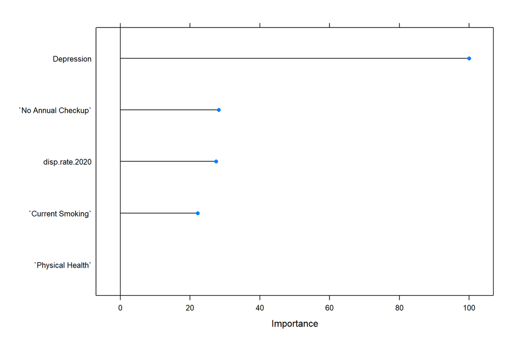

```r
# importance plot of predictor variables in final model
plot(varImp(elastic.net.model,scale=TRUE))
```

# Conclusion

The key finding from these analyses is that regional prescription opioid prescribing is still a significant predictor of drug overdose deaths but only accounts for 5% of the total variance in overdose death rates across counties in the US. The county-level prevalence of poor mental health or depression independently predicts approximately 4 times more variance in drug overdose death rates than prescription opioid dispensing rates. This finding is congruent with the observation that the number of opioid overdose deaths attributable to prescription opioids remained unchanged between 2015 and 2020 despite a more than 40% decline in prescribing. The lack of change in overdose deaths due to prescription opioids likely reflects that prescription opioids can still be easily procured by individuals for whom prescription opioids are the opioid of choice for abuse. Notwithstanding the national and regional trends, efforts to reduce unnecessary exposure to opioids among individuals in the community remains the best solution for reducing incident cases of opioid use disorder.

While the opioid epidemic is a national problem, other findings from these analyses underscore the importance of understanding regional dynamics and substance abuse patterns. For example, while opioid abuse is typically associated with the abuse of other drugs and alcohol at the individual level, the prevalence of binge drinking at the county level was negatively associated with drug overdose death rates. This association was driven by the very high prevalence of binge drinking in Wisconsin where drug overdose death rates were below the national average. Large cohort studies or case-control studies, which can evaluate individual-level factors, would likely be more informative than these county-level summary data in identifying the health factors that predispose an individual person to opioid abuse. However, the strong positive association between poor mental health and depression with drug overdose death rates in this analysis is consistent with prior research on risk factors for opioid abuse ([Manchikanti et al, 2007](https://www.wmpllc.org/ojs/index.php/jom/article/view/1172); [Sullivan, 2018](https://www.ingentaconnect.com/content/wk/cjpn/2018/00000034/00000009/art00010)).

A recent paper by [Aubry and Carr (2022)](https://www.frontiersin.org/articles/10.3389/fpain.2022.884674/full) reported on an analysis of prescription opioid sales and prescription opioid deaths on the state level from 2010 to 2019. Their analysis regressed the annual prescription opioid sales on the opioid overdose death rate by state and found a significant negative relationship in most states (i.e., *higher* opioid doses dispensed per capita were associated with *lower* overdose death rates). The present analysis refutes those findings, which are attributable to the fact the authors regressed two trended time series, which is known to induce spurious correlations ([Neifeld, 1927](https://www.tandfonline.com/doi/abs/10.1080/01621459.1927.10502965?journalCode=uasa20)). In this case, opioid overdose deaths were increasing over time as a result of the proliferation of fentanyl and other synthetic opioids while prescription opioid dispensing was declining over the same time frame. While there are several statistically appropriate methods for evaluating two trended time series, the analyses presented in this report remove the influence of time entirely to demonstrate that higher opioid prescribing rates do, indeed, remain positively associated with drug overdose death.

Overall, the results of this project suggest that reducing unnecessary prescription opioid exposure should remain a public health priority. In the context of the current state of the opioid epidemic, efforts to reduce the supply of illicit fentanyl and the prevalence of mental health issues leading to substance abuse may be the most impactful interventions for reducing opioid overdose deaths.